# Data summary of my five flux towers

Author

Johanna Schmidle

Published

Invalid Date

### C1. Site overview —-

```r
# read in data for my towers
library(readr)
library(dplyr)

my_towers <- c("CR-AqC", "SE-Svb", "CN-You", "US-Bi2", "AU-Lit")

tower_data <- read_csv("../data/snapshots/fluxnet_shuttle_snapshot_20261113T112721.csv") %>%
  filter(site_id %in% my_towers)
```

```r
 # Lookup-table for site id and country
country_lookup <- tibble(
  site_id = c("CR-AqC", "SE-Svb", "CN-You", "US-Bi2", "AU-Lit"),
  country = c("Costa Rica", "Sweden", "China", "United States", "Australia")
)

# add the country column
tower_data_country <- tower_data %>%
  left_join(country_lookup, by = "site_id")

# correct order
tower_data_overview <- tower_data_country %>%
  select(
    site_id,
    site_name,
    country,
    igbp,
    location_lat,
    location_long,
    first_year,
    last_year,
    data_hub,
    product_citation
  )

# and display table
print(tower_data_overview)
```

```
# A tibble: 5 × 10
  site_id site_name          country igbp  location_lat location_long first_year
  <chr>   <chr>              <chr>   <chr>        <dbl>         <dbl>      <dbl>
1 US-Bi2  Bouldin Island co… United… CRO          38.1         -122.        2017
2 SE-Svb  Svartberget        Sweden  ENF          64.3           19.8       2014
3 CR-AqC  Aquiares Coffee-F… Costa … EBF           9.94         -83.7       2009
4 CN-You  Yakou              China   GRA          38.0          100.        2015
5 AU-Lit  Litchfield         Austra… WSA         -13.2          131.        2015
# ℹ 3 more variables: last_year <dbl>, data_hub <chr>, product_citation <chr>
```

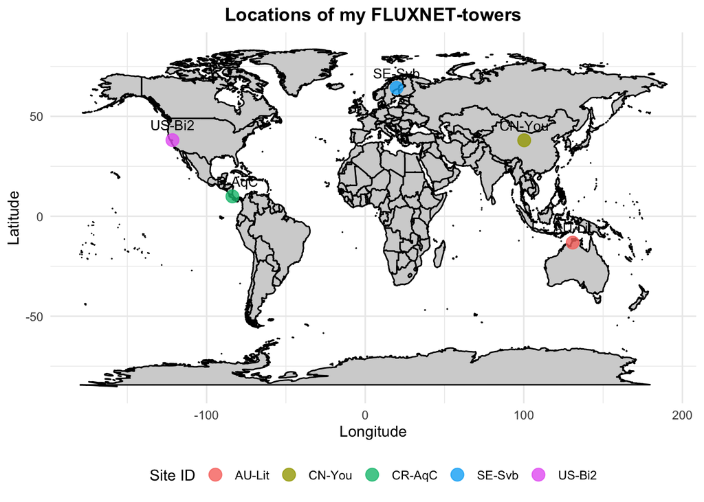

```r
# create map with site locataioins
library(ggplot2)
library(dplyr)
library(maps)


# load world map
world_map <- map_data("world")


ggplot() +
  # first the map in the background
  geom_polygon(
    data = world_map,
    aes(x = long, y = lat, group = group),
    fill = "lightgray",
    color = "black"
  ) +
  # add the location points
  geom_point(
    data = tower_data_overview,
    aes(x = location_long, y = location_lat, color = site_id),
    size = 4,
    alpha = 0.8
  ) +
  # add site name tags
  geom_text(
    data = tower_data_overview,
    aes(x = location_long, y = location_lat, label = site_id),
    vjust = -1,
    size = 3.5,
    color = "black"
  ) +
  # axes
  labs(
    title = "Locations of my FLUXNET-towers",
    x = "Longitude",
    y = "Latitude",
    color = "Site ID"
  ) +

  theme_minimal() +
  theme(
    plot.title = element_text(hjust = 0.5, face = "bold"),
    plot.subtitle = element_text(hjust = 0.5),
    legend.position = "bottom"
  )
```

### C2. Data coverage —–

```r
# create object hh_all that contains the data of all the towers (from exercise B)
### B3 Wrap it in a function -----------------------------------------
library(here)
library(readr)
library(dplyr)

read_hh <- function(zip_file) {

  keep <- c("TIMESTAMP_START", "TIMESTAMP_END", "TA_F", "SW_IN_F", "VPD_F", "P_F",
            "NETRAD", "G_F_MDS", "H_F_MDS", "H_F_MDS_QC", "LE_F_MDS", "LE_F_MDS_QC",
            "NEE_VUT_REF", "NEE_VUT_REF_QC", "GPP_NT_VUT_REF", "RECO_NT_VUT_REF")

  file_name <- tools::file_path_sans_ext(basename(zip_file))
  site_name <- strsplit(file_name, "_")[[1]][2]

  hh_name <- grep("FLUXMET_HH", unzip(zip_file, list = TRUE)$Name, value = TRUE)

  out_dir <- here("data", "raw", "unzipped")
  unzip(zip_file, files = hh_name, exdir = out_dir)

  read_csv(file.path(out_dir, hh_name),
           na = "-9999",
           col_select = any_of(keep),
           col_types = cols(TIMESTAMP_START = "c", TIMESTAMP_END = "c", .default = "d")) |>
    mutate(time = as.POSIXct(TIMESTAMP_START, format = "%Y%m%d%H%M", tz = "UTC"),
           site = site_name)
}

zip_files <- list.files(here("data", "raw"), pattern = "\\.zip$", full.names = TRUE)
stopifnot(length(zip_files) > 0)   # bricht mit klarer Meldung ab, statt still ein leeres Objekt zu erzeugen

hh_all <- lapply(zip_files, read_hh) |> bind_rows()
```

```r
#
library(dplyr)
library(ggplot2)
library(lubridate)  # to get the year out of Postix
library(tidyr)      # to change in not long format for the heat map

# prepare data for visualisation
hh_coverage <- hh_all %>%
  # get the year
  mutate(year = year(time)) %>%
  # calculate proportion of NEE_VUT_REF_QC == 0 per site and year
  group_by(site, year) %>%
  summarise(
    share_measured = mean(NEE_VUT_REF_QC == 0, na.rm = TRUE),
    .groups = "drop"
  ) %>%
  # fill up missing site+ year info with 0
  complete(site, year, fill = list(share_measured = 0))

# change format into not-long-format for the heat map
hh_coverage_wide <- hh_coverage %>%
  pivot_wider(
    names_from = year,
    values_from = share_measured
  )
```

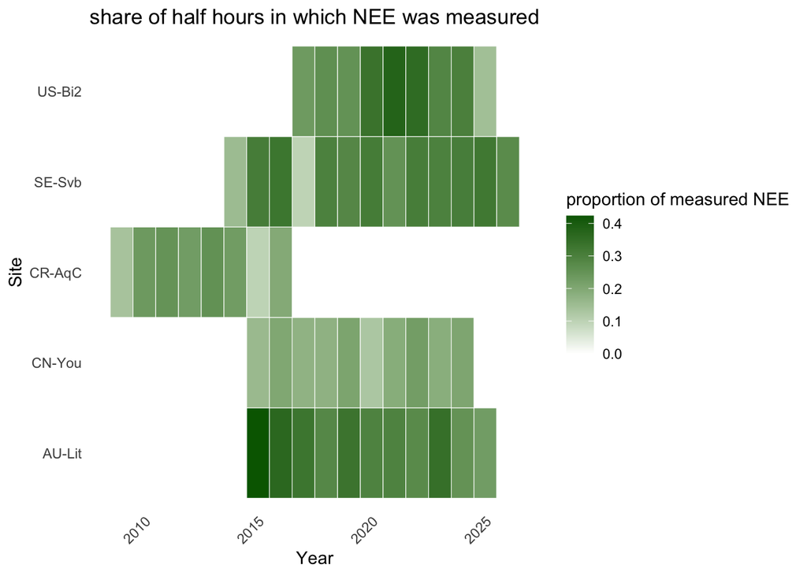

```r
### Print the heat map
ggplot(hh_coverage, aes(x = year, y = site, fill = share_measured)) +
  # Heatmap-Zellen
  geom_tile(color = "white") +
  # Farbskala (von 0 bis 1)
  scale_fill_gradient(
    low = "white",
    high = "darkgreen",
    name = "proportion of measured NEE"
  ) +
  # Achsenbeschriftungen
  labs(
    title = "share of half hours in which NEE was measured",
    x = "Year",
    y = "Site"
  ) +
  # Design anpassen
  theme_minimal() +
  theme(
    axis.text.x = element_text(angle = 45, hjust = 1),
    panel.grid = element_blank()
  )
```

The best data cover has the Australian site AU-Lit in 2015.

### C3. Summary statistics ——

```r
# data subset site for US
filtered_US <- hh_all[hh_all$site == "US-Bi2", ]

# Function to calculate statistics
calculate_stats <- function(data, variable) {

  mean_val <- mean(data[[variable]], na.rm = TRUE)
  min_val <- min(data[[variable]], na.rm = TRUE)
  max_val <- max(data[[variable]], na.rm = TRUE)
  missing_pct <- mean(is.na(data[[variable]])) * 100

  data.frame(
    Variable = variable,
    Mean = mean_val,
    Minimum = min_val,
    Maximum = max_val,
    `Missing values (%)` = missing_pct
  )
}

# vector with columns to calculate statistics
variables <- c("TA_F", "SW_IN_F", "VPD_F", "P_F", "NEE_VUT_REF", "GPP_NT_VUT_REF", "RECO_NT_VUT_REF", "H_F_MDS", "LE_F_MDS")

# catlucate statistics and store in a list
stats_list_US <- lapply(variables, function(var) calculate_stats(filtered_US, var))

# create one data frame
stats_df_US <- do.call(rbind, stats_list_US)

# transpone table
stats_df_transposed_US <- t(stats_df_US[, -1])  # delete 'variables'
stats_df_transposed_US <- as.data.frame(stats_df_transposed_US)
colnames(stats_df_transposed_US) <- stats_df_US$Variable
rownames(stats_df_transposed_US) <- c("Mean", "Minimum", "Maximum", "Missing values (%)")


new_colnames <- c(
  "Air temperature(°C)",
  "solar radiation (W/m²)",
  "VPD (kPa)",
  "Precipiatation (mm)",
  "NEE (µmol CO₂/m²/s)",
  "GPP (µmol CO₂/m²/s)",
  "RECO (µmol CO₂/m²/s)",
  "Sensible heat flux (W/m²)",
  "Latent heat flux  (W/m²)"
)

colnames(stats_df_transposed_US) <- new_colnames
```

```r
# data subset site for the other sites
filtered_CN <- hh_all[hh_all$site == "CN-You", ]
filtered_CR <- hh_all[hh_all$site == "CR-AqC", ]
filtered_SE <- hh_all[hh_all$site == "SE-Svb", ]
filtered_AU <- hh_all[hh_all$site == "AU-Lit", ]



# catlucate statistics and store in a list
stats_list_CN <- lapply(variables, function(var) calculate_stats(filtered_CN, var))
stats_list_CR <- lapply(variables, function(var) calculate_stats(filtered_CR, var))
stats_list_SE <- lapply(variables, function(var) calculate_stats(filtered_SE, var))
stats_list_AU <- lapply(variables, function(var) calculate_stats(filtered_AU, var))

# create one data frame
stats_df_CN <- do.call(rbind, stats_list_CN)
stats_df_CR <- do.call(rbind, stats_list_CR)
stats_df_SE <- do.call(rbind, stats_list_SE)
stats_df_AU <- do.call(rbind, stats_list_AU)

# transpone table
stats_df_transposed_CN <- t(stats_df_CN[, -1])  # delete 'variables'
stats_df_transposed_CN <- as.data.frame(stats_df_transposed_CN)
colnames(stats_df_transposed_CN) <- stats_df_CN$Variable
rownames(stats_df_transposed_CN) <- c("Mean", "Minimum", "Maximum", "Missing values (%)")

stats_df_transposed_CR <- t(stats_df_CR[, -1])  # delete 'variables'
stats_df_transposed_CR <- as.data.frame(stats_df_transposed_CR)
colnames(stats_df_transposed_CR) <- stats_df_CR$Variable
rownames(stats_df_transposed_CR) <- c("Mean", "Minimum", "Maximum", "Missing values (%)")

stats_df_transposed_SE <- t(stats_df_SE[, -1])  # delete 'variables'
stats_df_transposed_SE <- as.data.frame(stats_df_transposed_SE)
colnames(stats_df_transposed_SE) <- stats_df_SE$Variable
rownames(stats_df_transposed_SE) <- c("Mean", "Minimum", "Maximum", "Missing values (%)")

stats_df_transposed_AU <- t(stats_df_AU[, -1])  # delete 'variables'
stats_df_transposed_AU <- as.data.frame(stats_df_transposed_AU)
colnames(stats_df_transposed_AU) <- stats_df_AU$Variable
rownames(stats_df_transposed_AU) <- c("Mean", "Minimum", "Maximum", "Missing values (%)")

colnames(stats_df_transposed_CN) <- new_colnames
colnames(stats_df_transposed_CR) <- new_colnames
colnames(stats_df_transposed_SE) <- new_colnames
colnames(stats_df_transposed_AU) <- new_colnames
```

US site statistics

```r
# US site statistics
print(stats_df_transposed_US)
```

```
                   Air temperature(°C) solar radiation (W/m²) VPD (kPa)
Mean                          15.34061                228.185  8.173692
Minimum                       -2.60200                  0.000  0.000000
Maximum                       42.38000               1174.340 71.672000
Missing values (%)             0.00000                  0.000  0.000000
                   Precipiatation (mm) NEE (µmol CO₂/m²/s) GPP (µmol CO₂/m²/s)
Mean                        0.01883677            4.068172            3.965575
Minimum                     0.00000000          -57.873100          -20.695300
Maximum                    12.50000000           29.868500           77.021900
Missing values (%)          0.00000000            9.967295            9.967295
                   RECO (µmol CO₂/m²/s) Sensible heat flux (W/m²)
Mean                       7.984980e+00                 32.798470
Minimum                    5.411380e-07               -598.203000
Maximum                    2.844460e+01                580.625000
Missing values (%)         9.967295e+00                  9.948281
                   Latent heat flux  (W/m²)
Mean                              56.497461
Minimum                          -62.030500
Maximum                          600.347000
Missing values (%)                 9.948281
```

China site statistics

```r
print(stats_df_transposed_CN)
```

```
                   Air temperature(°C) solar radiation (W/m²) VPD (kPa)
Mean                         -4.019375               209.9783  2.076299
Minimum                     -31.343000                 0.0000  0.115000
Maximum                      42.440000              1400.0000 58.108000
Missing values (%)            0.000000                 0.0000  0.000000
                   Precipiatation (mm) NEE (µmol CO₂/m²/s) GPP (µmol CO₂/m²/s)
Mean                         0.1562259          -0.3826494                 NaN
Minimum                      0.0000000         -32.2648000                 Inf
Maximum                     10.0700000          32.0631000                -Inf
Missing values (%)           0.0000000           9.8378045                 100
                   RECO (µmol CO₂/m²/s) Sensible heat flux (W/m²)
Mean                                NaN                  10.28662
Minimum                             Inf                -124.09100
Maximum                            -Inf                 273.47600
Missing values (%)                  100                   0.00000
                   Latent heat flux  (W/m²)
Mean                                27.1447
Minimum                           -122.4240
Maximum                            523.8300
Missing values (%)                   0.0000
```

Costa Rica site statistics

```r
print(stats_df_transposed_CR)
```

```
                   Air temperature(°C) solar radiation (W/m²) VPD (kPa)
Mean                          19.52577               196.3056  3.301574
Minimum                       12.09000                 0.0000  0.000000
Maximum                       28.14000              1359.4000 21.954000
Missing values (%)             0.00000                 0.0000  0.000000
                   Precipiatation (mm) NEE (µmol CO₂/m²/s) GPP (µmol CO₂/m²/s)
Mean                          0.174201           -2.015547                 NaN
Minimum                       0.000000          -49.592300                 Inf
Maximum                      48.550000           42.605700                -Inf
Missing values (%)            0.000000            7.038558                 100
                   RECO (µmol CO₂/m²/s) Sensible heat flux (W/m²)
Mean                                NaN                 37.949033
Minimum                             Inf               -233.926000
Maximum                            -Inf                539.827000
Missing values (%)                  100                  1.309035
                   Latent heat flux  (W/m²)
Mean                              63.023838
Minimum                         -185.764000
Maximum                          701.966000
Missing values (%)                 8.285564
```

Sweden site statistics

```r
print(stats_df_transposed_SE)
```

```
                   Air temperature(°C) solar radiation (W/m²) VPD (kPa)
Mean                          3.521348             107.229254  2.490778
Minimum                     -28.702000               0.000000  0.006000
Maximum                      30.970000            1011.950000 33.035000
Missing values (%)            2.759056               2.759056  2.759056
                   Precipiatation (mm) NEE (µmol CO₂/m²/s) GPP (µmol CO₂/m²/s)
Mean                         0.0334276         -306.642792         -303.399142
Minimum                      0.0000000        -9999.000000        -9999.000000
Maximum                     20.9500000           32.940000           65.510000
Missing values (%)           2.7590564            2.759056            2.759056
                   RECO (µmol CO₂/m²/s) Sensible heat flux (W/m²)
Mean                        -303.689724                 -374.1998
Minimum                    -9999.000000                -9999.0000
Maximum                       14.455900                  993.4600
Missing values (%)             2.759056                    0.0000
                   Latent heat flux  (W/m²)
Mean                              -383.3959
Minimum                          -9999.0000
Maximum                            974.1000
Missing values (%)                   0.0000
```

Australia site statistics

```r
print(stats_df_transposed_AU)
```

```
                   Air temperature(°C) solar radiation (W/m²) VPD (kPa)
Mean                          26.38599               216.1682  11.59603
Minimum                       12.92000                 0.0000   0.00000
Maximum                       39.06000              1232.0000  57.44900
Missing values (%)             0.00000                 0.0000   0.00000
                   Precipiatation (mm) NEE (µmol CO₂/m²/s) GPP (µmol CO₂/m²/s)
Mean                         0.0921727           -1.053537            5.087427
Minimum                      0.0000000          -75.323400          -39.763300
Maximum                     49.0000000           47.937700           75.323400
Missing values (%)           0.0000000           11.310561           22.927037
                   RECO (µmol CO₂/m²/s) Sensible heat flux (W/m²)
Mean                       3.977108e+00                  38.44555
Minimum                    1.138610e-06                -100.00000
Maximum                    1.838000e+01                 696.00000
Missing values (%)         2.292704e+01                  11.23123
                   Latent heat flux  (W/m²)
Mean                               84.71915
Minimum                           -99.00000
Maximum                          1448.00000
Missing values (%)                 11.23123
```

### C4. Time series —–

```r
# attach a date group
filtered_US$date <- as.Date(filtered_US$time)
filtered_CN$date <- as.Date(filtered_CN$time)
filtered_CR$date <- as.Date(filtered_CR$time)
filtered_SE$date <- as.Date(filtered_SE$time)
filtered_AU$date <- as.Date(filtered_AU$time)

# aggregate daily means
daily_means_US <- filtered_US %>%
  group_by(date) %>%  # Nach Datum gruppieren
  summarise(
    NEE = mean(NEE_VUT_REF, na.rm = TRUE),
    GPP = mean(GPP_NT_VUT_REF, na.rm = TRUE),
    RECO = mean(RECO_NT_VUT_REF, na.rm = TRUE)
  )

daily_means_CN <- filtered_CN %>%
  group_by(date) %>%  # Nach Datum gruppieren
  summarise(
    NEE = mean(NEE_VUT_REF, na.rm = TRUE),
    GPP = mean(GPP_NT_VUT_REF, na.rm = TRUE),
    RECO = mean(RECO_NT_VUT_REF, na.rm = TRUE)
  )

daily_means_CR <- filtered_CR %>%
  group_by(date) %>%  # Nach Datum gruppieren
  summarise(
    NEE = mean(NEE_VUT_REF, na.rm = TRUE),
    GPP = mean(GPP_NT_VUT_REF, na.rm = TRUE),
    RECO = mean(RECO_NT_VUT_REF, na.rm = TRUE)
  )

daily_means_SE <- filtered_SE %>%
  group_by(date) %>%  # Nach Datum gruppieren
  summarise(
    NEE = mean(NEE_VUT_REF, na.rm = TRUE),
    GPP = mean(GPP_NT_VUT_REF, na.rm = TRUE),
    RECO = mean(RECO_NT_VUT_REF, na.rm = TRUE)
  )

daily_means_AU <- filtered_AU %>%
  group_by(date) %>%  # Nach Datum gruppieren
  summarise(
    NEE = mean(NEE_VUT_REF, na.rm = TRUE),
    GPP = mean(GPP_NT_VUT_REF, na.rm = TRUE),
    RECO = mean(RECO_NT_VUT_REF, na.rm = TRUE)
  )
```

[figure not shown]

```r
library(ggplot2)
library(gridExtra)
library(tidyr)

all_data <- list(
  US = daily_means_US,
  CN = daily_means_CN,
  CR = daily_means_CR,
  SE = daily_means_SE,
  AU = daily_means_AU
)

# 2. Farben für die Variablen festlegen
colors <- c("GPP" = "green", "NEE" = "blue", "RECO" = "red")

# 3. Einzelne Plots für jedes Land erstellen (ohne Funktion)
plot_US <- ggplot(all_data$US, aes(x = date)) +
  geom_line(aes(y = GPP, color = "GPP"), linewidth = 0.7, na.rm = TRUE) +
  geom_line(aes(y = NEE, color = "NEE"), linewidth = 0.7, na.rm = TRUE) +
  geom_line(aes(y = RECO, color = "RECO"), linewidth = 0.7, na.rm = TRUE) +
  scale_color_manual(values = colors) +
  labs(title = "USA", x = "Date", y = "flux") +
  theme_minimal() +
  theme(legend.position = "top", plot.title = element_text(hjust = 0.5))

plot_CN <- ggplot(all_data$CN, aes(x = date)) +
  geom_line(aes(y = GPP, color = "GPP"), linewidth = 0.7, na.rm = TRUE) +
  geom_line(aes(y = NEE, color = "NEE"), linewidth = 0.7, na.rm = TRUE) +
  geom_line(aes(y = RECO, color = "RECO"), linewidth = 0.7, na.rm = TRUE) +
  scale_color_manual(values = colors) +
  labs(title = "China", x = "Date", y = "flux") +
  theme_minimal() +
  theme(legend.position = "top", plot.title = element_text(hjust = 0.5))

plot_CR <- ggplot(all_data$CR, aes(x = date)) +
  geom_line(aes(y = GPP, color = "GPP"), linewidth = 0.7, na.rm = TRUE) +
  geom_line(aes(y = NEE, color = "NEE"), linewidth = 0.7, na.rm = TRUE) +
  geom_line(aes(y = RECO, color = "RECO"), linewidth = 0.7, na.rm = TRUE) +
  scale_color_manual(values = colors) +
  labs(title = "Costa Rica", x = "Date", y = "flux") +
  theme_minimal() +
  theme(legend.position = "top", plot.title = element_text(hjust = 0.5))

plot_SE <- ggplot(all_data$SE, aes(x = date)) +
  geom_line(aes(y = GPP, color = "GPP"), linewidth = 0.7, na.rm = TRUE) +
  geom_line(aes(y = NEE, color = "NEE"), linewidth = 0.7, na.rm = TRUE) +
  geom_line(aes(y = RECO, color = "RECO"), linewidth = 0.7, na.rm = TRUE) +
  scale_color_manual(values = colors) +
  labs(title = "Sweden", x = "Date", y = "flux") +
  theme_minimal() +
  theme(legend.position = "top", plot.title = element_text(hjust = 0.5))

plot_AU <- ggplot(all_data$AU, aes(x = date)) +
  geom_line(aes(y = GPP, color = "GPP"), linewidth = 0.7, na.rm = TRUE) +
  geom_line(aes(y = NEE, color = "NEE"), linewidth = 0.7, na.rm = TRUE) +
  geom_line(aes(y = RECO, color = "RECO"), linewidth = 0.7, na.rm = TRUE) +
  scale_color_manual(values = colors) +
  labs(title = "Australia", x = "Date", y = "flux") +
  theme_minimal() +
  theme(legend.position = "top", plot.title = element_text(hjust = 0.5))

# 4. Alle Plots in einer Abbildung anordnen (5 Zeilen, 1 Spalte)
grid.arrange(plot_US, plot_CN, plot_CR, plot_SE, plot_AU, ncol = 1, top = "Time series GPP, NEE and RECO")
```

Unfortunately this doesn’t work. I couldn’t find the mistake. Because of this time seres are plotted separately below.

```r
# unit conversion from CO2 to C
daily_means_US <- daily_means_US[,c(2:4)]*1.0378
daily_means_CN <- daily_means_CN[,c(2:4)]*1.0378
daily_means_CR <- daily_means_CR[,c(2:4)]*1.0378
daily_means_SE <- daily_means_SE[,c(2:4)]*1.0378
daily_means_AU <- daily_means_AU[,c(2:4)]*1.0378
```

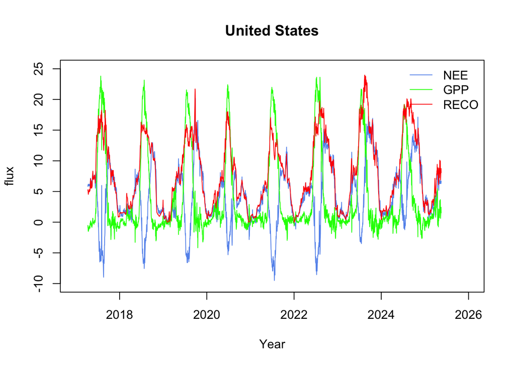

```r
#par(mfrow= c(5,1))
library(dplyr)

daily_means_US <- hh_all %>%
  filter(site == "US-Bi2") %>%
  mutate(date = as.Date(time)) %>%
  group_by(date) %>%
  summarise(
    NEE  = mean(NEE_VUT_REF,     na.rm = TRUE),
    GPP  = mean(GPP_NT_VUT_REF,  na.rm = TRUE),
    RECO = mean(RECO_NT_VUT_REF, na.rm = TRUE),
    .groups = "drop"
  )

stopifnot(nrow(daily_means_US) > 0)

plot(daily_means_US$date, daily_means_US$NEE, type = "l", col = "cornflowerblue",
     xlab = "Year", ylab = "flux", main = "United States", ylim = c(-10, 25))
lines(daily_means_US$date, daily_means_US$GPP,  col = "green")
lines(daily_means_US$date, daily_means_US$RECO, col = "red")
legend("topright", lty = 1, legend = c("NEE", "GPP", "RECO"),
       col = c("cornflowerblue", "green", "red"), bty = "n")
```

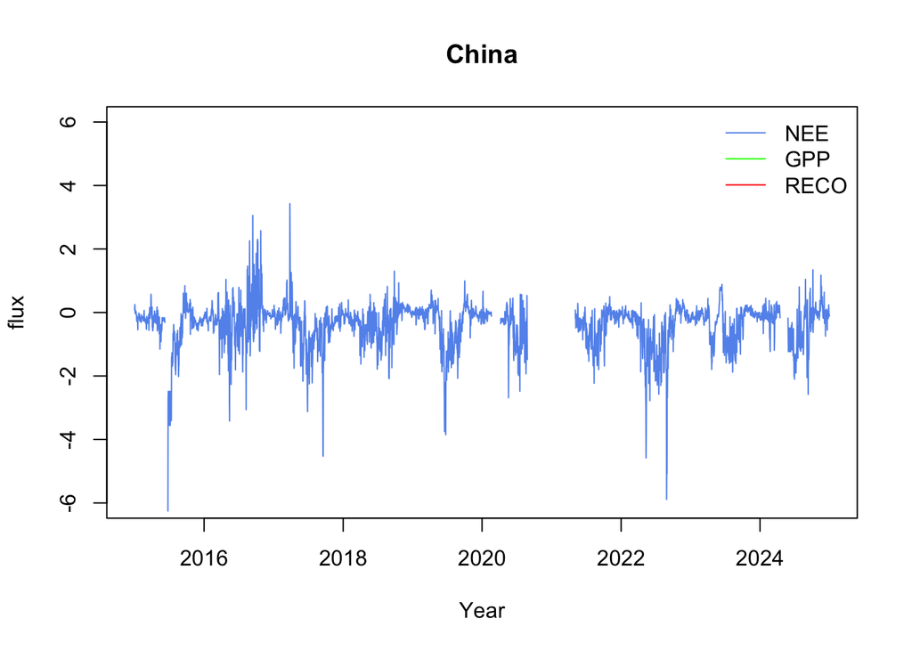

```r
library(dplyr)

daily_means_CN <- hh_all %>%
  filter(site == "CN-You") %>%
  mutate(date = as.Date(time)) %>%
  group_by(date) %>%
  summarise(
    NEE  = mean(NEE_VUT_REF,     na.rm = TRUE),
    GPP  = mean(GPP_NT_VUT_REF,  na.rm = TRUE),
    RECO = mean(RECO_NT_VUT_REF, na.rm = TRUE),
    .groups = "drop"
  )

stopifnot(nrow(daily_means_CN) > 0)

plot(daily_means_CN$date, daily_means_CN$NEE, type = "l", col = "cornflowerblue",
     xlab = "Year", ylab = "flux", main = "China", ylim = c(-6, 6))
lines(daily_means_CN$date, daily_means_CN$GPP,  col = "green")
lines(daily_means_CN$date, daily_means_CN$RECO, col = "red")
legend("topright", lty = 1, legend = c("NEE", "GPP", "RECO"),
       col = c("cornflowerblue", "green", "red"), bty = "n")
```

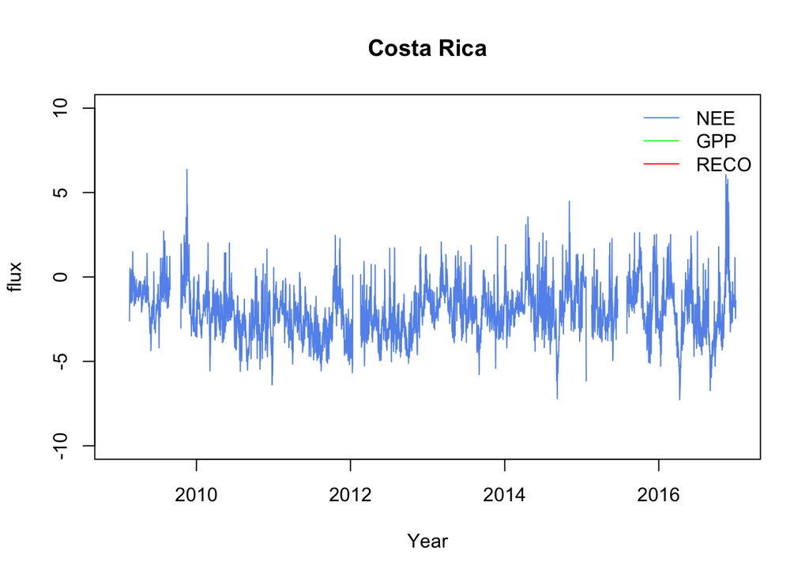

```r
# Costa Rica
library(dplyr)

daily_means_CR <- hh_all %>%
  filter(site == "CR-AqC") %>%
  mutate(date = as.Date(time)) %>%
  group_by(date) %>%
  summarise(
    NEE  = mean(NEE_VUT_REF,     na.rm = TRUE),
    GPP  = mean(GPP_NT_VUT_REF,  na.rm = TRUE),
    RECO = mean(RECO_NT_VUT_REF, na.rm = TRUE),
    .groups = "drop"
  )

stopifnot(nrow(daily_means_CR) > 0)

plot(daily_means_CR$date, daily_means_CR$NEE, type = "l", col = "cornflowerblue",
     xlab = "Year", ylab = "flux", main = "Costa Rica", ylim = c(-10, 10))
lines(daily_means_CR$date, daily_means_CR$GPP,  col = "green")
lines(daily_means_CR$date, daily_means_CR$RECO, col = "red")
legend("topright", lty = 1, legend = c("NEE", "GPP", "RECO"),
       col = c("cornflowerblue", "green", "red"), bty = "n")
```

China and Costa Rica have no values for GPP and Reco!

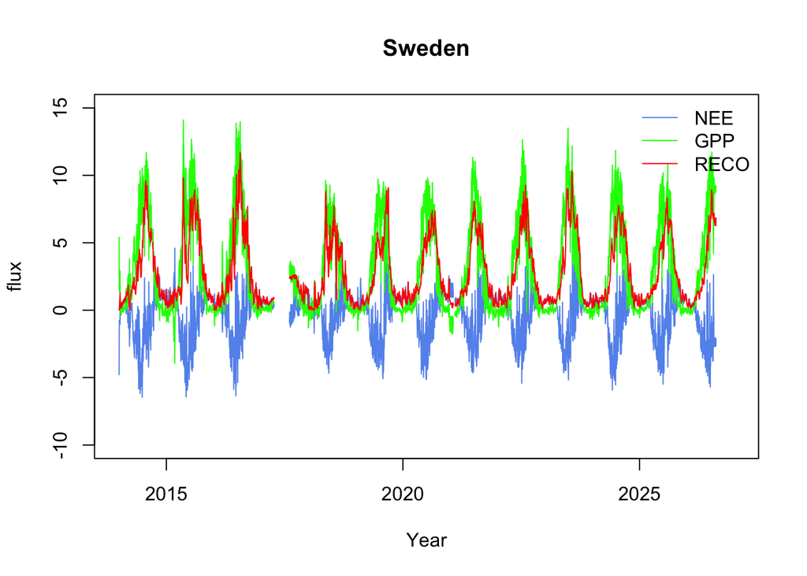

```r
# Sweden




library(dplyr)

daily_means_SE <- hh_all %>%
  filter(site == "SE-Svb") %>%
  mutate(date = as.Date(time)) %>%
  group_by(date) %>%
  summarise(
    NEE  = mean(NEE_VUT_REF,     na.rm = TRUE),
    GPP  = mean(GPP_NT_VUT_REF,  na.rm = TRUE),
    RECO = mean(RECO_NT_VUT_REF, na.rm = TRUE),
    .groups = "drop"
  )

stopifnot(nrow(daily_means_SE) > 0)

# filter data
daily_means_SE$RECO[daily_means_SE$RECO == -9999] <- NA
daily_means_SE$RECO[daily_means_SE$RECO < -100] <- NA
daily_means_SE$NEE[daily_means_SE$NEE == -9999] <- NA
daily_means_SE$NEE[daily_means_SE$NEE < -100] <- NA
daily_means_SE$GPP[daily_means_SE$GPP == -9999] <- NA
daily_means_SE$GPP[daily_means_SE$GPP < -100] <- NA

plot(daily_means_SE$date, daily_means_SE$NEE, type = "l", col = "cornflowerblue",
     xlab = "Year", ylab = "flux", main = "Sweden", ylim = c(-10, 15))
lines(daily_means_SE$date, daily_means_SE$GPP,  col = "green")
lines(daily_means_SE$date, daily_means_SE$RECO, col = "red")
legend("topright", lty = 1, legend = c("NEE", "GPP", "RECO"),
       col = c("cornflowerblue", "green", "red"), bty = "n")
```

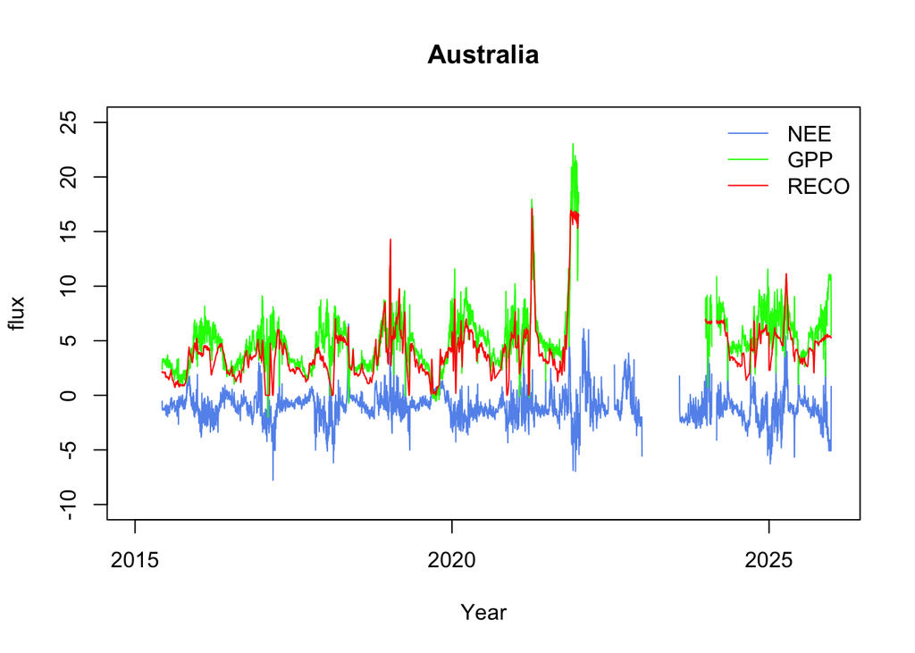

```r
# Australia
library(dplyr)

daily_means_AU <- hh_all %>%
  filter(site == "AU-Lit") %>%
  mutate(date = as.Date(time)) %>%
  group_by(date) %>%
  summarise(
    NEE  = mean(NEE_VUT_REF,     na.rm = TRUE),
    GPP  = mean(GPP_NT_VUT_REF,  na.rm = TRUE),
    RECO = mean(RECO_NT_VUT_REF, na.rm = TRUE),
    .groups = "drop"
  )

stopifnot(nrow(daily_means_AU) > 0)

plot(daily_means_AU$date, daily_means_AU$NEE, type = "l", col = "cornflowerblue",
     xlab = "Year", ylab = "flux", main = "Australia", ylim = c(-10, 25))
lines(daily_means_AU$date, daily_means_AU$GPP,  col = "green")
lines(daily_means_AU$date, daily_means_AU$RECO, col = "red")
legend("topright", lty = 1, legend = c("NEE", "GPP", "RECO"),
       col = c("cornflowerblue", "green", "red"), bty = "n")
```

### C5. Diurnal cycles —–

```r
library(dplyr)
library(lubridate)
library(tidyr)
library(ggplot2)

flux <- hh_all
meta <- tower_data
```

```r
# apparently there are still -9999 values uinstead of NAs in the object. I don#t know how, they shouldn#t be there as they were redefined when the data was read in. But somehow I still need to do this but only for Sweden.
flux$NEE_VUT_REF[flux$NEE_VUT_REF == -9999] <- NA
flux$LE_F_MDS[flux$LE_F_MDS == -9999] <- NA
```

```r
flux <- flux %>%
  left_join(meta %>% select(site_id, location_lat), by = c("site" = "site_id")) %>%
  mutate(
    month = month(time),
    # define months for season
    season_north = case_when(
      month %in% c(12, 1, 2)  ~ "Winter",
      month %in% c(3, 4, 5)   ~ "Spring",
      month %in% c(6, 7, 8)   ~ "Summer",
      month %in% c(9, 10, 11) ~ "Autumn"
    ),
    # Southern hemisphere (lat < 0): season changed by six months
    season = case_when(
      location_lat >= 0 ~ season_north,
      season_north == "Winter" ~ "Summer",
      season_north == "Summer" ~ "Winter",
      season_north == "Spring" ~ "Autumn",
      season_north == "Autumn" ~ "Spring"
    ),
    season = factor(season, levels = c("Spring", "Summer", "Autumn", "Winter"))
  )
```

The seasons are defined by month, not by a calender date. The latitude data is attached to define whether site are located on the northern or southern hemisphere. If situated on the southern hemisphere, seasons are reversed.

```r
# calculate mean diurnal fluc
diurnal <- flux %>%
  mutate(hour = hour(time) + minute(time) / 60) %>%   # half-hours
  group_by(site, season, hour) %>%
  summarise(
    NEE = mean(NEE_VUT_REF, na.rm = TRUE),
    LE  = mean(LE_F_MDS,  na.rm = TRUE),
    .groups = "drop"
  ) %>%
  pivot_longer(cols = c(NEE, LE), names_to = "variable", values_to = "value")
```

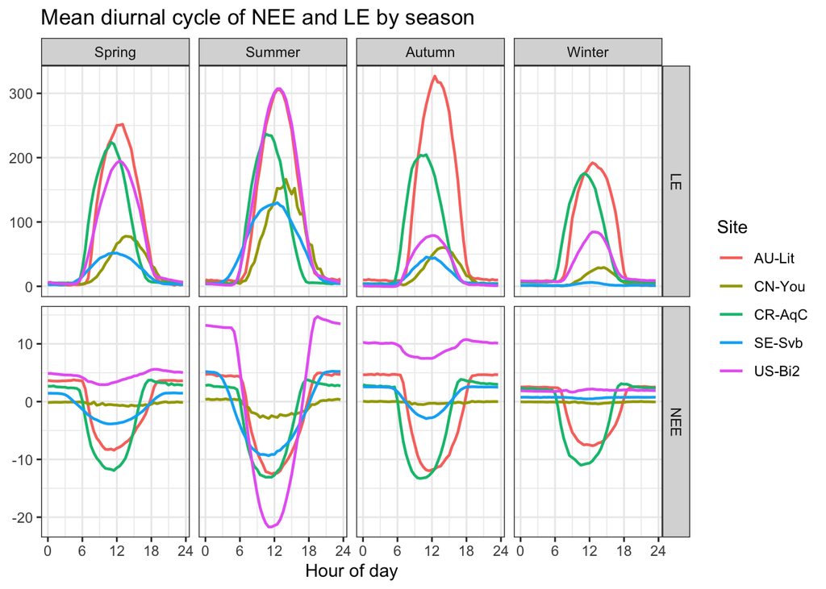

```r
ggplot(diurnal, aes(x = hour, y = value, color = site)) +
  geom_line(linewidth = 0.8) +
  facet_grid(variable ~ season, scales = "free_y") +
  scale_x_continuous(breaks = seq(0, 24, 6)) +
  labs(
    x = "Hour of day",
    y = NULL,
    color = "Site",
    title = "Mean diurnal cycle of NEE and LE by season",
  ) +
  theme_bw()
```

### C6. Energy balance

```r
library(dplyr)
library(ggplot2)


flux <- flux %>%
  mutate(across(where(is.numeric), ~ na_if(., -9999)))

# find tower with netrad and g
flux %>%
  group_by(site) %>%
  summarise(
    n_netrad = sum(!is.na(NETRAD)),
    n_G      = sum(!is.na(G_F_MDS)),
    n_both   = sum(!is.na(NETRAD) & !is.na(G_F_MDS))
  )
```

```
# A tibble: 5 × 4
  site   n_netrad    n_G n_both
  <chr>     <int>  <int>  <int>
1 AU-Lit   168788 172352 161818
2 CN-You    96862 170253  96862
3 CR-AqC   140256      0      0
4 SE-Svb   219534 220365 218283
5 US-Bi2   140440 143522 140440
```

```r
site_sel <- "SE-Svb"   # Sweden

eb <- flux %>%
  filter(site == site_sel,
         H_F_MDS_QC  == 0,
         LE_F_MDS_QC == 0) %>%
  mutate(
    turb  = H_F_MDS + LE_F_MDS,   # turbulent fluxes (y-axis)
    avail = NETRAD - G_F_MDS      # available energy (x-axis)
  ) %>%
  filter(!is.na(turb), !is.na(avail))
```

```r
# fit a linear regression
fit <- lm(turb ~ avail, data = eb)

slope     <- coef(fit)[["avail"]]
intercept <- coef(fit)[["(Intercept)"]]
r2        <- summary(fit)$r.squared

slope; intercept; r2
```

```
[1] 0.7793383
```

```
[1] -2.346061
```

```
[1] 0.8878973
```

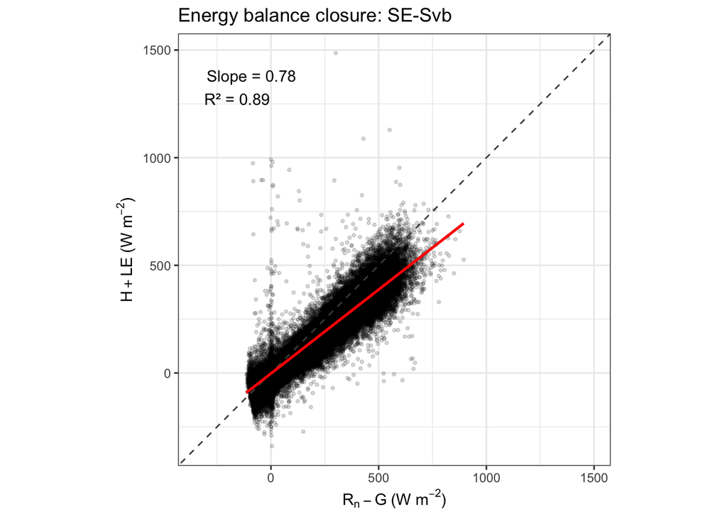

```r
# Plotting
lims <- range(c(eb$avail, eb$turb), na.rm = TRUE)

ggplot(eb, aes(x = avail, y = turb)) +
  geom_point(alpha = 0.15, size = 0.8) +
  geom_abline(slope = 1, intercept = 0, linetype = "dashed", color = "grey30") +
  geom_smooth(method = "lm", se = FALSE, color = "red", linewidth = 0.9) +
  annotate("text",
           x = lims[1], y = lims[2], hjust = -0.1, vjust = 1.5,
           label = sprintf("Slope = %.2f\nR² = %.2f", slope, r2)) +
  coord_fixed(xlim = lims, ylim = lims) +
  labs(
    x = expression(R[n] - G~"(W m"^-2*")"),
    y = expression(H + LE~"(W m"^-2*")"),
    title = paste("Energy balance closure:", site_sel)
  ) +
  theme_bw() +
  theme(aspect.ratio = 1)
```

Generally the ecosystem in Costa Rica seems to take up the most carbon when we look at the whole year. The carbon and laten heat fluxes also are the most constant at this tower, which is not surprising as it is a tropical forest there. However, midday carbon fixation rates are very high ( higher than Costa Rica) at the cropland in the United States. This is also the site taht shows the highest variabilty through the seasons. This, however, is also not surprising as crops grow fast but then get harvested. Surprising was the high latent heat flux in the Australian savannah in Autumn. The data from the swedish tower data was annoying to handle as the exchange of the -9999 with the NAs didn’t work and I couldn’t find the problem for a long time. The data covoreage however, is not too good, especially for the tower in Costa Rica. this tower doensn’t have data anymore for the last ten years.

### Data and citation

FLUXNET data products (ONEFlux v1.3, 2026 release), downloaded with the FLUXNET Shuttle from AmeriFlux, the ICOS Carbon Portal and TERN. Licence: CC-BY-4.0.

Pastorello et al. (2020), Scientific Data 7, 225, https://doi.org/10.1038/s41597-020-0534-3

FLUXNET data products were produced and harmonized by eddy covariance regional networks and data processing centers, including AmeriFlux, ChinaFlux, European Fluxes Database, ICOS, JapanFlux, KoFlux, OzFlux, SAEON, and TERN. These products also include a modified version of ERA5 hourly data provided by the Copernicus Climate Change Service.

## Tower data

Beringer, J., Hutley, L., Northwood, M. (2026): Litchfield FLUXNET Release 2026_r1. Version 2026_r1. Terrestrial Ecosystem Research Network (TERN). (Dataset).

Bonnefond, J., Gay, F., Roupsard, O., Van Den Meersche, K. (2026). Fluxnet Archive Product from Aquiares Coffee-Flux, 2009–2016, FLUXNET, https://hdl.handle.net/11676/yRjv2loTLxMX5_elU4L2aqKw

Camilo Rey-Sanchez, Carlos Tianxin Wang, Daphne Szutu, Kyle Hemes, Joseph Verfaillie, Dennis Baldocchi (2026), AmeriFlux FLUXNET-1F US-Bi2 Bouldin Island corn, Ver. v1.3_r1, AmeriFlux AMP, (Dataset). https://doi.org/10.17190/AMF/1871135

Liu, S., Che, T., Xu, Z. (2026). Fluxnet Archive Product from Yakou, 2015–2024, FLUXNET, https://hdl.handle.net/11676/vRR8XgOrD3OP9aSNCJm9qe2P

Peichl, M., Nilsson, M., Larmanou, E., Smith, P., Marklund, P., De Simon, G., Lofvenius, P., Dignam, R., Holst, J., Molder, M., Andersson, T., Boschetti, F., Kozii, N., Linderson, M., Lindgren, K., Ottosson-Löfvenius, M. (2026). Fluxnet Archive Product from Svartberget, 2014-01-01–2026-09-06, FLUXNET, https://hdl.handle.net/11676/aOE0EYzWDWCQYR2pK8kcNORZ